# Costos de la Provincia de Buenos Aires de presos/as por infracción a la ley 23737 (2005-2019)

Por **Lucas Pecina** lucaspecina@gmail.com

**Unidad de Planificación Estrategica** - Ministerio de Justicia - Provincia de Buenos Aires

Este trabajo fue realizado utilizando el lenguaje R. Es totalmente reproducible. Para consultas sobre los datos y otras partes del código, pueden escribir al mail señalado arriba.

```r
library(dplyr)
library(ggplot2)
library(tidyr)
library(readxl)
library(zoo)
```

### Pre-procesamiento de datos

La fuente principal es el conjunto de datos del SNEEP (Sistema Nacional de Estadísticas sobre Ejecución de la Pena) del Ministerio de Justicia de la Nacion. El dataset esta disponible en la pagina de datos del Ministerio http://datos.jus.gob.ar/dataset/sneep con el nombre de **“Sistema Nacional de Estadísticas sobre Ejecución de la Pena - SNEEP - 2002-2018 - unificado”**. Este recurso contiene los censos del SNEEP correspondientes a los años 2002 a 2018 organizados en un archivo unificado.

El dataset contiene datos hasta el 31 de diciembre de 2018, por lo tanto, utilizare la informacion de un informe de la Unidad de Gestion y Coordinacion Estadistica del Servicio Penitenciario Bonaerense, del Ministerio de Justicia de la PBA. (detallare mas adelante)

Tal como aparece en el github del SNEEP https://github.com/datos-justicia-argentina/Sistema-Nacional-de-Estadisticas-sobre-Ejecucion-de-la-Pena-SNEEP/blob/master/Sistema-Nacional-de-Estadisticas-sobre-Ejecucion-de-la-Pena-SNEEP-metadata.md :

"En este conjunto de datos se detallan los datos recopilados en el censo realizado sobre el total de la población detenida al día 31 de diciembre de cada año, en cada establecimiento de la República Argentina. La unidad de análisis son las personas alojadas en los establecimientos.

El censo recaba la siguiente información sobre cada interno: edad, sexo, nacionalidad, estado civil, nivel de instrucción, situación laboral, lugar de residencia, jurisdicción judicial, situación legal, fecha de detención, fecha de condena, establecimiento de procedencia, tipo de delitos imputado, participación en trabajo remunerado, en actividades de capacitación laboral, en actividades recreativas, asistencia médica, vistas, alteraciones al orden, sanciones disciplinarias, calificaciones de conducta, tentativas de fugas o evasiones, tentativa de suicidios, lesiones recibidas, duración de la condena, medidas de seguridad, reincidencia, régimen de progresividad, salidas transitorias, régimen de semilibertad, programe de prelibertad, prisión discontinua, semidetención, reducción de pena, mujeres alojadas con sus hijos.

```r
#sneep_unificado <- read_csv("sneep-unificado-2002-2018.csv")

head(sneep_unificado)
```

| anio_censo | provincia_sneep_id | provincia_descripcion | establecimiento_id | establecimiento_descripcion | edad | genero_id | genero_descripcion | nacionalidad_id | nacionalidad_descripcion | estado_civil_id | estado_civil_descripcion | nivel_instruccion_id | nivel_instruccion_descripcion | ultima_situacion_laboral_id | ultima_situacion_laboral_descripcion | capacitacion_laboral_al_ingresar_id | capacitacion_laboral_al_ingresar_descripcion | ultimo_lugar_residencia_id | ultimo_lugar_residencia_descripcion | ultima_provincia_residencia_sneep_id | ultima_provincia_residencia_descripcion | jurisdiccion_id | jurisdiccion_descripcion | situacion_legal_id | situacion_legal_descripcion | fecha_detencion | fecha_condenado | establecimiento_procedencia_id | establecimiento_procedencia_descripcion | … |
| --- | --- | --- | --- | --- | --- | --- | --- | --- | --- | --- | --- | --- | --- | --- | --- | --- | --- | --- | --- | --- | --- | --- | --- | --- | --- | --- | --- | --- | --- | --- |
| 2002 | 1 | Buenos Aires | 18 | UNIDAD 13 - JUNIN | 27 | 1 | Masculino | 1 | Argentina | 6 | Concubino | 2 | Primario incompleto | 2 | Trabajador de tiempo parcial | 1 | Tiene algún oficio | 2 | Urbano | 1 | Buenos Aires | 1 | PROVINCIAL - Buenos Aires | 2 | Procesado | 27/09/2001 00:00:00 | NA | 3 | Deriv. de una instit. Policial | … |
| 2002 | 1 | Buenos Aires | 18 | UNIDAD 13 - JUNIN | 25 | 1 | Masculino | 1 | Argentina | 6 | Concubino | 3 | Primario completo | 3 | Desocupado | 3 | No tiene ni oficio ni profesión | 1 | Rural | 1 | Buenos Aires | 1 | PROVINCIAL - Buenos Aires | 2 | Procesado | 15/07/2002 00:00:00 | NA | 3 | Deriv. de una instit. Policial | … |
| 2002 | 1 | Buenos Aires | 18 | UNIDAD 13 - JUNIN | 33 | 1 | Masculino | 1 | Argentina | 6 | Concubino | 3 | Primario completo | 1 | Trabajador de tiempo completo | 2 | Tiene alguna profesión | 1 | Rural | 1 | Buenos Aires | 1 | PROVINCIAL - Buenos Aires | 2 | Procesado | 10/03/2000 00:00:00 | NA | 3 | Deriv. de una instit. Policial | … |
| 2002 | 1 | Buenos Aires | 18 | UNIDAD 13 - JUNIN | 44 | 1 | Masculino | 1 | Argentina | 6 | Concubino | 3 | Primario completo | 2 | Trabajador de tiempo parcial | 1 | Tiene algún oficio | 2 | Urbano | 1 | Buenos Aires | 1 | PROVINCIAL - Buenos Aires | 2 | Procesado | 26/11/2002 00:00:00 | NA | 3 | Deriv. de una instit. Policial | … |
| 2002 | 1 | Buenos Aires | 18 | UNIDAD 13 - JUNIN | 23 | 1 | Masculino | 1 | Argentina | 6 | Concubino | 3 | Primario completo | 2 | Trabajador de tiempo parcial | 1 | Tiene algún oficio | 2 | Urbano | 1 | Buenos Aires | 1 | PROVINCIAL - Buenos Aires | 2 | Procesado | 30/11/2000 00:00:00 | NA | 3 | Deriv. de una instit. Policial | … |
| 2002 | 1 | Buenos Aires | 18 | UNIDAD 13 - JUNIN | 29 | 1 | Masculino | 1 | Argentina | 6 | Concubino | 3 | Primario completo | 3 | Desocupado | 3 | No tiene ni oficio ni profesión | 2 | Urbano | 1 | Buenos Aires | 1 | PROVINCIAL - Buenos Aires | 2 | Procesado | 17/10/2002 00:00:00 | NA | 2 | Deriv. de otro establecimiento | … |

```r
colnames(sneep_unificado)
```

```
 [1] "anio_censo"                                         "provincia_sneep_id"
 [3] "provincia_descripcion"                              "establecimiento_id"
 [5] "establecimiento_descripcion"                        "edad"
 [7] "genero_id"                                          "genero_descripcion"
 [9] "nacionalidad_id"                                    "nacionalidad_descripcion"
[11] "estado_civil_id"                                    "estado_civil_descripcion"
[13] "nivel_instruccion_id"                               "nivel_instruccion_descripcion"
[15] "ultima_situacion_laboral_id"                        "ultima_situacion_laboral_descripcion"
[17] "capacitacion_laboral_al_ingresar_id"                "capacitacion_laboral_al_ingresar_descripcion"
[19] "ultimo_lugar_residencia_id"                         "ultimo_lugar_residencia_descripcion"
[21] "ultima_provincia_residencia_sneep_id"               "ultima_provincia_residencia_descripcion"
[23] "jurisdiccion_id"                                    "jurisdiccion_descripcion"
[25] "situacion_legal_id"                                 "situacion_legal_descripcion"
[27] "fecha_detencion"                                    "fecha_condenado"
[29] "establecimiento_procedencia_id"                     "establecimiento_procedencia_descripcion"
```

[output cut: 29 more lines]

Vemos que el dataset cuenta con 87 columnas. En el github https://github.com/datos-justicia-argentina/Sistema-Nacional-de-Estadisticas-sobre-Ejecucion-de-la-Pena-SNEEP/blob/master/Sistema-Nacional-de-Estadisticas-sobre-Ejecucion-de-la-Pena-SNEEP-metadata.md se encuentra el diccionario de variables. Usare estas descripciones para explicar el proceso.

Para filtrar y dejar solo los datos que nos interesan, seguiremos la siguiente secuencia de pasos:

- En primer lugar, tomaremos los individuos cuyo año de censo sea 2005 o superiores. Uso la variable **anio_censo (int)**: año en el que se realizó el censo.
- En segundo lugar, debemos dejar solo aquellos individuos cuya causa figure en la jurisdiccion de la provincia de buenos aires. Tal como dice la variable **jurisdiccion_id (int)**: código de la jurisdicción judicial interviniente en la causa penal motivo de la detención
- Luego, detectamos que hay diversos establecimientos que no son de competencia de la PBA, sino Federales y de otros lugares. Para eliminarlos del dataset, identificamos aquellos establecimientos segun su id que contengan la palabra FEDERAL, SPF o FED. Uso la variable **establecimiento_id (int)**: código del establecimiento penitenciario.

```r
establecimientos  <- sneep_unificado %>% filter(jurisdiccion_id==1 & anio_censo>=2005 &
   (delito1_descripcion=='Infracción ley n° 23.737 (estupefacientes)' | delito2_descripcion=='Infracción ley n° 23.737 (estupefacientes)' |
    delito3_descripcion=='Infracción ley n° 23.737 (estupefacientes)' | delito4_descripcion=='Infracción ley n° 23.737 (estupefacientes)' |
    delito5_descripcion=='Infracción ley n° 23.737 (estupefacientes)')) %>%
  group_by(establecimiento_descripcion, establecimiento_id) %>% summarise(cantidad=n())

print(establecimientos)
```

| establecimiento_descripcion | establecimiento_id | cantidad |
| --- | --- | --- |
| ALCAIDIA DEPARTAMENTAL AVELLANEDA | 565 | 30 |
| ALCAIDIA DEPARTAMENTAL JOSE C. PAZ (EX U.55) | 352 | 5 |
| ALCAIDIA DEPARTAMENTAL LA PLATA II | 566 | 11 |
| ALCAIDIA DEPARTAMENTAL LA PLATA III | 567 | 85 |
| ALCAIDIA DEPARTAMENTAL LOMAS DE ZAMORA | 568 | 44 |
| ALCAIDIA DEPARTAMENTAL ROBERTO PETTINATO | 569 | 26 |
| ALCAIDIA DEPARTAMENTAL SAN MARTIN | 570 | 14 |
| ALCAIDIA PENITENCIARIA BATAN (EX U.44) | 271 | 73 |
| ALCAIDIA PENITENCIARIA JUNIN (EX U.49) | 321 | 153 |
| ALCAIDIA PENITENCIARIA MALVINAS ARGENTINAS (EX U.53) | 291 | 19 |

[output cut: 101 more lines]

- Por ultimo, dejamos solo los establecimientos que esten ubicados en la PBA con la variable **provincia_sneep_id (int)**: código de provincia SNEEP donde se encuentra el establecimiento penitenciario censado.

> El dataset principal que usaremos queda conformado de la siguiente manera

```r
ley23737 <- sneep_unificado %>% filter(jurisdiccion_id==1 & provincia_sneep_id==1 & anio_censo>=2005 &
        (delito1_descripcion=='Infracción ley n° 23.737 (estupefacientes)' | delito2_descripcion=='Infracción ley n° 23.737 (estupefacientes)' |
         delito3_descripcion=='Infracción ley n° 23.737 (estupefacientes)' | delito4_descripcion=='Infracción ley n° 23.737 (estupefacientes)' |
         delito5_descripcion=='Infracción ley n° 23.737 (estupefacientes)') &
        !establecimiento_id %in% c(63,64,65,67,68,70,87,89,350,358,505,537) & # != 'FEDERAL'
        !establecimiento_id %in% c(66,71,72,73,74,75,76,78,84,85,86,88,90,91,92)) # != 'SPF'

head(ley23737, 10)
```

| anio_censo | provincia_sneep_id | provincia_descripcion | establecimiento_id | establecimiento_descripcion | edad | genero_id | genero_descripcion | nacionalidad_id | nacionalidad_descripcion | estado_civil_id | estado_civil_descripcion | nivel_instruccion_id | nivel_instruccion_descripcion | ultima_situacion_laboral_id | ultima_situacion_laboral_descripcion | capacitacion_laboral_al_ingresar_id | capacitacion_laboral_al_ingresar_descripcion | ultimo_lugar_residencia_id | ultimo_lugar_residencia_descripcion | ultima_provincia_residencia_sneep_id | ultima_provincia_residencia_descripcion | jurisdiccion_id | jurisdiccion_descripcion | situacion_legal_id | situacion_legal_descripcion | fecha_detencion | fecha_condenado | establecimiento_procedencia_id | establecimiento_procedencia_descripcion | … |
| --- | --- | --- | --- | --- | --- | --- | --- | --- | --- | --- | --- | --- | --- | --- | --- | --- | --- | --- | --- | --- | --- | --- | --- | --- | --- | --- | --- | --- | --- | --- |
| 2005 | 1 | Buenos Aires | 118 | UNIDAD 29 - MELCHOR ROMERO | 27 | 1 | Masculino | 1 | Argentina | 1 | Soltero | 4 | Secundario incompleto | 2 | Trabajador de tiempo parcial | 1 | Tiene algún oficio | 2 | Urbano | 1 | Buenos Aires | 1 | PROVINCIAL - Buenos Aires | 1 | Condenado | NA | 22/03/2009 00:00:00 | 2 | Deriv. de otro establecimiento | … |
| 2005 | 1 | Buenos Aires | 245 | UNIDAD 36 - MAGDALENA | 27 | 1 | Masculino | 1 | Argentina | 1 | Soltero | 3 | Primario completo | 2 | Trabajador de tiempo parcial | 1 | Tiene algún oficio | 2 | Urbano | 1 | Buenos Aires | 1 | PROVINCIAL - Buenos Aires | 1 | Condenado | 22/05/2004 00:00:00 | 17/12/2004 00:00:00 | 3 | Deriv. de una instit. Policial | … |
| 2005 | 1 | Buenos Aires | 249 | UNIDAD 26 - LISANDRO OLMOS | 49 | 1 | Masculino | 1 | Argentina | 6 | Concubino | 2 | Primario incompleto | 2 | Trabajador de tiempo parcial | 2 | Tiene alguna profesión | 2 | Urbano | 1 | Buenos Aires | 1 | PROVINCIAL - Buenos Aires | 2 | Procesado | 09/05/2001 00:00:00 | NA | 2 | Deriv. de otro establecimiento | … |
| 2005 | 1 | Buenos Aires | 249 | UNIDAD 26 - LISANDRO OLMOS | 55 | 1 | Masculino | 1 | Argentina | 6 | Concubino | 2 | Primario incompleto | 3 | Desocupado | 3 | No tiene ni oficio ni profesión | 2 | Urbano | 1 | Buenos Aires | 1 | PROVINCIAL - Buenos Aires | 1 | Condenado | 28/01/2002 00:00:00 | 19/11/2011 00:00:00 | 2 | Deriv. de otro establecimiento | … |
| 2005 | 1 | Buenos Aires | 251 | UNIDAD 37 - BARKER | 32 | 1 | Masculino | 1 | Argentina | 1 | Soltero | 3 | Primario completo | 2 | Trabajador de tiempo parcial | 3 | No tiene ni oficio ni profesión | 2 | Urbano | 1 | Buenos Aires | 1 | PROVINCIAL - Buenos Aires | 2 | Procesado | 27/10/2004 00:00:00 | NA | 3 | Deriv. de una instit. Policial | … |
| 2005 | 1 | Buenos Aires | 251 | UNIDAD 37 - BARKER | 22 | 1 | Masculino | 1 | Argentina | 6 | Concubino | 2 | Primario incompleto | 1 | Trabajador de tiempo completo | 1 | Tiene algún oficio | 2 | Urbano | 1 | Buenos Aires | 1 | PROVINCIAL - Buenos Aires | 2 | Procesado | 13/01/2004 00:00:00 | NA | 3 | Deriv. de una instit. Policial | … |
| 2006 | 1 | Buenos Aires | 18 | UNIDAD 13 - JUNIN | 34 | 1 | Masculino | 1 | Argentina | 1 | Soltero | 3 | Primario completo | 2 | Trabajador de tiempo parcial | 3 | No tiene ni oficio ni profesión | 2 | Urbano | 1 | Buenos Aires | 1 | PROVINCIAL - Buenos Aires | 2 | Procesado | 24/04/2006 00:00:00 | NA | 3 | Deriv. de una instit. Policial | … |
| 2006 | 1 | Buenos Aires | 18 | UNIDAD 13 - JUNIN | 41 | 1 | Masculino | 1 | Argentina | 1 | Soltero | 3 | Primario completo | 1 | Trabajador de tiempo completo | 1 | Tiene algún oficio | 2 | Urbano | 1 | Buenos Aires | 1 | PROVINCIAL - Buenos Aires | 2 | Procesado | 30/05/2006 00:00:00 | NA | 3 | Deriv. de una instit. Policial | … |
| 2006 | 1 | Buenos Aires | 18 | UNIDAD 13 - JUNIN | 61 | 1 | Masculino | 6 | Uruguaya | 2 | Casado | 3 | Primario completo | 1 | Trabajador de tiempo completo | 1 | Tiene algún oficio | 2 | Urbano | 1 | Buenos Aires | 1 | PROVINCIAL - Buenos Aires | 2 | Procesado | 14/07/2006 00:00:00 | NA | 2 | Deriv. de otro establecimiento | … |
| 2006 | 1 | Buenos Aires | 18 | UNIDAD 13 - JUNIN | 26 | 1 | Masculino | 1 | Argentina | 1 | Soltero | 3 | Primario completo | 1 | Trabajador de tiempo completo | 1 | Tiene algún oficio | 2 | Urbano | 1 | Buenos Aires | 1 | PROVINCIAL - Buenos Aires | 2 | Procesado | 29/12/2004 00:00:00 | NA | 3 | Deriv. de una instit. Policial | … |

### Analisis de datos

Para tener una idea general, contamos la cantidad de presos/as por año que hubo por infracciones a la ley 23737.

```r
cuantos_por_anio <- ley23737 %>% group_by(anio_censo) %>% summarise(presos_ley23737= n())

print(cuantos_por_anio)
```

| anio_censo | presos_ley23737 |
| --- | --- |
| 2005 | 6 |
| 2006 | 334 |
| 2007 | 1010 |
| 2008 | 1462 |
| 2009 | 1696 |
| 2010 | 2113 |
| 2011 | 2500 |
| 2012 | 2534 |
| 2013 | 2544 |
| 2014 | 2435 |

[output cut: 4 more lines]

Esto lo comparamos sobre el total de presos/as para todos los delitos. Esto lo hacemos por cada año

```r
cantidad_delitos_poranio <- sneep_unificado %>% filter(jurisdiccion_id==1 & provincia_sneep_id==1 & anio_censo>=2005 &
                                                         !establecimiento_id %in% c(63,64,65,67,68,70,87,89,350,358,505,537) &
                                                         !establecimiento_id %in% c(66,71,72,73,74,75,76,78,84,85,86,88,90,91,92)) %>%
                                                         group_by(anio_censo) %>% summarise(presos_total= n())

print(cantidad_delitos_poranio)
```

| anio_censo | presos_total |
| --- | --- |
| 2005 | 12788 |
| 2006 | 20109 |
| 2007 | 21491 |
| 2008 | 22769 |
| 2009 | 22858 |
| 2010 | 25874 |
| 2011 | 26871 |
| 2012 | 26780 |
| 2013 | 27860 |
| 2014 | 30177 |

[output cut: 4 more lines]

Graficamos la evolucion temporal

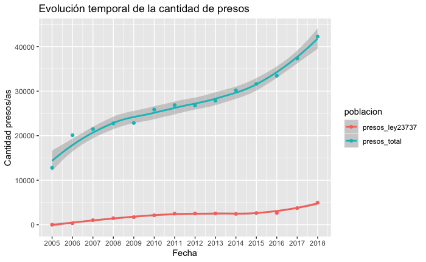

Ahora es necesario cargar la informacion sobre los presupuestos destinados al sistema penitenciario de la PBA en cada año. El presupuesto se extrajo de la información brindada por la Dirección Provincial de Presupuesto Público, disponible en https://www.gba.gob.ar/hacienda_y_finanzas/direccion_provincial_de_presupuesto_publico

```r
#presupuesto_spb <- read_excel("presupuesto_spb_por_año.xlsx")
print(presupuesto_spb)
```

| anio | presupuesto |
| --- | --- |
| 2005 | 480095252 |
| 2006 | 568460089 |
| 2007 | 840723598 |
| 2008 | 977027549 |
| 2009 | 1173467090 |
| 2010 | 1444603505 |
| 2011 | 1897422230 |
| 2012 | 2534895960 |
| 2013 | 3330242960 |
| 2014 | 4319197000 |

[output cut: 4 more lines]

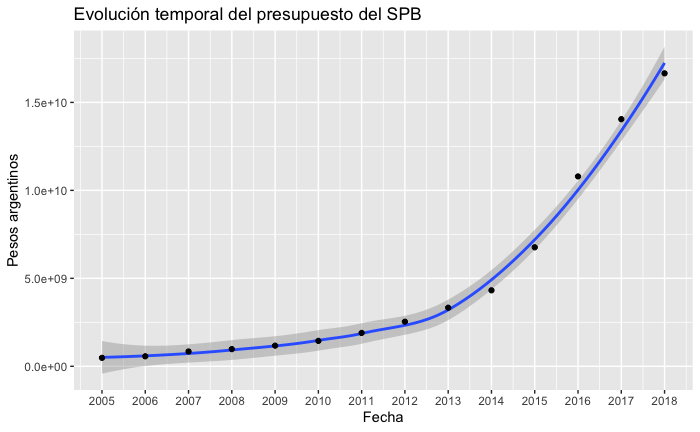

```r
#presupuesto_spb <- read_excel("presupuesto_spb_por_año.xlsx")
ggplot(presupuesto_spb, aes(x = anio, y = presupuesto)) +
    geom_smooth() + geom_point() + scale_x_continuous("Fecha",breaks = seq(2005,2018,1)) + ggtitle("Evolución temporal del presupuesto del SPB") + xlab("Año") + ylab("Pesos argentinos")
```

El trabajo consistira de tres metodos de estimacion de los costos de presos/as por infraccion a la ley 23737.

> **Metodo 1 - Estimacion con valores al 31 de diciembre**: Usaremos los datos tal como vienen en el SNEEP para calcular la proporcion de presos por delitos por estupefacientes sobre el total de delitos (por cada año). Luego asumiremos que esta distribucion se mantiene en todo el año y calcularemos los costos actualizados por inflacion usando estos valores.

> **Metodo 2 - Estimacion con imputaciones lineales**: Se realiza una recta desde un periodo temporal al siguiente (de año a año) y se simula la cantidad de presos (totales y por ley 23737) de cada mes segun el valor de la recta: *presos_año_anterior+((presos_año_actual-presos_año_anterior)/12)*mes*. Luego, se utilizan estas cifras para calcular los costos actualizados por inflacion.

> **Metodo 3 - Estimacion con imputacion por media**: Se toma la media entre los dos puntos (cantidad presos año anterior y cantidad presos año actual). Esos valores se utilizaran para todos los meses para calcular costos y actualizar por inflacion.

### **Metodo 1 - Estimacion con valores al 31 de diciembre**

Para aproximar los costos de los presos/as por infraccion a la ley 23737, se calcula la proporcion de este subconjunto de individuos sobre la totalidad de individuos. Luego se utiliza esa proporcion sobre el presupuesto destinado en ese año para estimar el monto destinado a dicho subconjunto.

```r
#aca calculo la proporcion de presos por droga sobre el total de presos para cada año
ley23737_sobre_total <- cuantos_por_anio %>% inner_join(cantidad_delitos_poranio, by='anio_censo')

ley23737_sobre_total_copia <- ley23737_sobre_total # este va a ser utilizado mas adelante, en el metodo 2

ley23737_sobre_total <- ley23737_sobre_total %>% mutate(presos_23737_relativo=presos_ley23737/presos_total)
colnames(ley23737_sobre_total) <- c('anio','presos_ley23737','presos_total','presos_23737_relativo')

#junto el resultado con el presupuesto para cada año
ley23737_sobre_total <- ley23737_sobre_total %>% inner_join(presupuesto_spb,by='anio')

print(ley23737_sobre_total)
```

| anio | presos_ley23737 | presos_total | presos_23737_relativo | presupuesto |
| --- | --- | --- | --- | --- |
| 2005 | 6 | 12788 | 0.0004691899 | 480095252 |
| 2006 | 334 | 20109 | 0.0166094783 | 568460089 |
| 2007 | 1010 | 21491 | 0.0469964171 | 840723598 |
| 2008 | 1462 | 22769 | 0.0642101102 | 977027549 |
| 2009 | 1696 | 22858 | 0.0741972176 | 1173467090 |
| 2010 | 2113 | 25874 | 0.0816649919 | 1444603505 |
| 2011 | 2500 | 26871 | 0.0930371032 | 1897422230 |
| 2012 | 2534 | 26780 | 0.0946228529 | 2534895960 |
| 2013 | 2544 | 27860 | 0.0913137114 | 3330242960 |
| 2014 | 2435 | 30177 | 0.0806905922 | 4319197000 |

[output cut: 4 more lines]

```r
data_2019 <- c(2019,    4915,   45366,  0.108341,   23417065600 ) # estos son los datos (ordenados segun las columnas de droga_sobre_total)

ley23737_sobre_total <- rbind(ley23737_sobre_total, data_2019)

print(ley23737_sobre_total)
```

| anio | presos_ley23737 | presos_total | presos_23737_relativo | presupuesto |
| --- | --- | --- | --- | --- |
| 2005 | 6 | 12788 | 0.0004691899 | 480095252 |
| 2006 | 334 | 20109 | 0.0166094783 | 568460089 |
| 2007 | 1010 | 21491 | 0.0469964171 | 840723598 |
| 2008 | 1462 | 22769 | 0.0642101102 | 977027549 |
| 2009 | 1696 | 22858 | 0.0741972176 | 1173467090 |
| 2010 | 2113 | 25874 | 0.0816649919 | 1444603505 |
| 2011 | 2500 | 26871 | 0.0930371032 | 1897422230 |
| 2012 | 2534 | 26780 | 0.0946228529 | 2534895960 |
| 2013 | 2544 | 27860 | 0.0913137114 | 3330242960 |
| 2014 | 2435 | 30177 | 0.0806905922 | 4319197000 |

[output cut: 5 more lines]

Por ultimo, debemos corregir los costos por la inflacion, para saber a cuanto equivale al valor del peso actual (marzo 2020). Tomamos los costos para los presos/as por infraccion a la ley 23737 y los actualizamos en función del Indice de Precios del Instituto de Trabajo y Economia, de la Fundacion German Abdala.

Cargo datos de inflacion

```r
#indice_precios_consumidor <- read_excel("C:/Users/Usuario/Desktop/Lucas/1- pe/5-presos/DATA/indice_precios_consumidor.xlsx")
print(indice_precios_consumidor)
```

| mes | anio | inflacion |
| --- | --- | --- |
| 12 | 2005 | 0.011132856 |
| 1 | 2006 | 0.012758471 |
| 2 | 2006 | 0.003963253 |
| 3 | 2006 | 0.012053653 |
| 4 | 2006 | 0.009725139 |
| 5 | 2006 | 0.004679973 |
| 6 | 2006 | 0.004842281 |
| 7 | 2006 | 0.006170788 |
| 8 | 2006 | 0.005625171 |
| 9 | 2006 | 0.008993574 |

[output cut: 160 more lines]

Se utiliza la formula acumulada: precio_anterior*(1+porcentaje_variacion_mensual) para calcularlo.

```r
#primero hago join con anios_meses
metodo1 <- ley23737_sobre_total %>% inner_join(anios_meses %>% filter(anio>2005 | mes==12),by='anio') %>% mutate(presupuesto_mensual=presupuesto/12) %>%
  mutate(costo_presos23737_mensual= presupuesto_mensual*presos_23737_relativo)
metodo1 <- metodo1 %>% select(c('anio','mes','presos_ley23737','presos_total','presos_23737_relativo','presupuesto','presupuesto_mensual','costo_presos23737_mensual' ))

#calculo inflacion
actualizados <- c()
for(i in 1:nrow(metodo1)){
  presupuesto <- metodo1$costo_presos23737_mensual[i]
  for(j in i:(nrow(indice_precios_consumidor)-1)){
    presupuesto <- presupuesto*(1+indice_precios_consumidor$inflacion[j+1])}
  actualizados <- c(actualizados, presupuesto)}
metodo1['costo_presos23737_mensual_actualizado'] <- actualizados

print(metodo1)
```

| anio | mes | presos_ley23737 | presos_total | presos_23737_relativo | presupuesto | presupuesto_mensual | costo_presos23737_mensual | costo_presos23737_mensual_actualizado |
| --- | --- | --- | --- | --- | --- | --- | --- | --- |
| 2005 | 12 | 6 | 12788 | 0.0004691899 | 480095252 | 40007938 | 18771.32 | 547583.5 |
| 2006 | 1 | 334 | 20109 | 0.0166094783 | 568460089 | 47371674 | 786818.79 | 22663366.5 |
| 2006 | 2 | 334 | 20109 | 0.0166094783 | 568460089 | 47371674 | 786818.79 | 22573900.4 |
| 2006 | 3 | 334 | 20109 | 0.0166094783 | 568460089 | 47371674 | 786818.79 | 22305043.2 |
| 2006 | 4 | 334 | 20109 | 0.0166094783 | 568460089 | 47371674 | 786818.79 | 22090212.8 |
| 2006 | 5 | 334 | 20109 | 0.0166094783 | 568460089 | 47371674 | 786818.79 | 21987312.8 |
| 2006 | 6 | 334 | 20109 | 0.0166094783 | 568460089 | 47371674 | 786818.79 | 21881357.1 |
| 2006 | 7 | 334 | 20109 | 0.0166094783 | 568460089 | 47371674 | 786818.79 | 21747160.0 |
| 2006 | 8 | 334 | 20109 | 0.0166094783 | 568460089 | 47371674 | 786818.79 | 21625512.8 |
| 2006 | 9 | 334 | 20109 | 0.0166094783 | 568460089 | 47371674 | 786818.79 | 21432755.7 |

[output cut: 159 more lines]

Agrupo por años y resumo la informacion.

```r
metodo1_agrupado <- metodo1 %>% group_by(anio) %>% summarise(presos_total_31dic=first(presos_total),
                                                                   presos_23737_31dic=first(presos_ley23737),
                                                                   presupuesto=first(presupuesto),
                                                                   presupuesto_mensual=first(presupuesto_mensual),
                                                                   proporcion_presos23737=mean(presos_23737_relativo),
                                                                   costo_presos23737_anual=sum(costo_presos23737_mensual),
                                                                   costo_presos23737_anual_actualizado=sum(costo_presos23737_mensual_actualizado))
print(metodo1_agrupado)
```

| anio | presos_total_31dic | presos_23737_31dic | presupuesto | presupuesto_mensual | proporcion_presos23737 | costo_presos23737_anual | costo_presos23737_anual_actualizado |
| --- | --- | --- | --- | --- | --- | --- | --- |
| 2005 | 12788 | 6 | 480095252 | 40007938 | 0.0004691899 | 1.877132e+04 | 547583.5 |
| 2006 | 20109 | 334 | 568460089 | 47371674 | 0.0166094783 | 9.441826e+06 | 261555533.0 |
| 2007 | 21491 | 1010 | 840723598 | 70060300 | 0.0469964171 | 3.951100e+07 | 950277273.8 |
| 2008 | 22769 | 1462 | 977027549 | 81418962 | 0.0642101102 | 6.273505e+07 | 1224186498.0 |
| 2009 | 22858 | 1696 | 1173467090 | 97788924 | 0.0741972176 | 8.706799e+07 | 1486888939.1 |
| 2010 | 25874 | 2113 | 1444603505 | 120383625 | 0.0816649919 | 1.179735e+08 | 1663846125.4 |
| 2011 | 26871 | 2500 | 1897422230 | 158118519 | 0.0930371032 | 1.765307e+08 | 2025714734.5 |
| 2012 | 26780 | 2534 | 2534895960 | 211241330 | 0.0946228529 | 2.398591e+08 | 2240538031.4 |
| 2013 | 27860 | 2544 | 3330242960 | 277520247 | 0.0913137114 | 3.040968e+08 | 2274485246.5 |
| 2014 | 30177 | 2435 | 4319197000 | 359933083 | 0.0806905922 | 3.485186e+08 | 1937636381.4 |

[output cut: 5 more lines]

Grafico los costos.

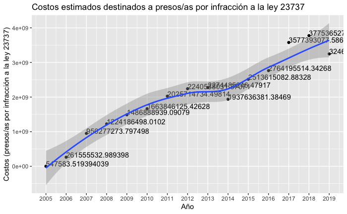

```r
ggplot(metodo1_agrupado, aes(anio, costo_presos23737_anual_actualizado)) + geom_point()  + geom_text(aes(label=costo_presos23737_anual_actualizado),hjust=0, vjust=0) + geom_smooth() + scale_x_continuous(breaks=metodo1_agrupado$anio) + ggtitle("Costos estimados destinados a presos/as por infracción a la ley 23737") + xlab("Año") + ylab("Costos (presos/as por infracción a la ley 23737)")
```

**COSTO FINAL DE PRESOS/AS POR INFRACCION A LA LEY 23737 (2005/2019) - METODO 1**

Sumo todos los años para que nos de el costo total:

```r
print(paste('Usando el Metodo 1 (valores al 31 dic), el costo total (2005-2019) de los presos/as por infraccion a la ley 23737: $', sum(metodo1$costo_presos23737_mensual)))
```

```
[1] "Usando el Metodo 1 (valores al 31 dic), el costo total (2005-2019) de los presos/as por infraccion a la ley 23737: $ 8692336446.3127"
```

```r
print(paste('Usando el Metodo 1 (valores al 31 dic), el costo total (2005-2019) de los presos/as por infraccion a la ley 23737, actualizado por inflacion es: $', sum(metodo1$costo_presos23737_mensual_actualizado)))
```

```
[1] "Usando el Metodo 1 (valores al 31 dic), el costo total (2005-2019) de los presos/as por infraccion a la ley 23737, actualizado por inflacion es: $ 29943062029.858"
```

### **Metodo 2: Imputacion mensual por aproximaciones lineales**

Comenzamos con la copia del conjunto de datos que realizamos anteriormente

```r
# ley23737_sobre_total_copia <- ley23737_sobre_total
colnames(ley23737_sobre_total_copia) <- c('anio','presos_ley23737','presos_total')

print(ley23737_sobre_total_copia)
```

| anio | presos_ley23737 | presos_total |
| --- | --- | --- |
| 2005 | 6 | 12788 |
| 2006 | 334 | 20109 |
| 2007 | 1010 | 21491 |
| 2008 | 1462 | 22769 |
| 2009 | 1696 | 22858 |
| 2010 | 2113 | 25874 |
| 2011 | 2500 | 26871 |
| 2012 | 2534 | 26780 |
| 2013 | 2544 | 27860 |
| 2014 | 2435 | 30177 |

[output cut: 4 more lines]

Lo que queremos hacer es “simular” para cada mes de cada año cuantos presos hay en total y cuantos por infraccion a la ley 23737, de una forma que siga una linea recta que vaya del valor de un año al siguiente (de los datos analizados provenientes de SNEEP). Luego calcular las estadisticas correspondientes.

Para eso comienzo haciendo un join con un dataset que contiene la estructura buscada

```r
para_calculo_23737 <- c(6,6,334,1010,1462,1696,2113,2500,2534,2544,2435,2616,2642,3730)
ley23737_sobre_total_copia['cantidad_anterior_23737'] <- para_calculo_23737

para_calculo_total <- c(12788,12788,20109,21491,22769,22858,25874,26871,26780,27860,30177,31619,33461,37342)
ley23737_sobre_total_copia['cantidad_anterior_total'] <- para_calculo_total

para_2019 <- c(2019,4915,45366,4960,42255)
ley23737_sobre_total_copia <- ley23737_sobre_total_copia %>% rbind(para_2019)

metodo2_23737 <- ley23737_sobre_total_copia %>% inner_join(anios_meses, by='anio')

print(metodo2_23737)
```

| anio | presos_ley23737 | presos_total | cantidad_anterior_23737 | cantidad_anterior_total | mes |
| --- | --- | --- | --- | --- | --- |
| 2005 | 6 | 12788 | 6 | 12788 | 1 |
| 2005 | 6 | 12788 | 6 | 12788 | 2 |
| 2005 | 6 | 12788 | 6 | 12788 | 3 |
| 2005 | 6 | 12788 | 6 | 12788 | 4 |
| 2005 | 6 | 12788 | 6 | 12788 | 5 |
| 2005 | 6 | 12788 | 6 | 12788 | 6 |
| 2005 | 6 | 12788 | 6 | 12788 | 7 |
| 2005 | 6 | 12788 | 6 | 12788 | 8 |
| 2005 | 6 | 12788 | 6 | 12788 | 9 |
| 2005 | 6 | 12788 | 6 | 12788 | 10 |

[output cut: 170 more lines]

Visualizo como quedaria conformado el valor de cada mes. En los siguientes graficos, cada punto es un mes particular. Estos siguien una linea recta desde un año al siguiente. Utilizaremos estas cifras como estimaciones mensuales.

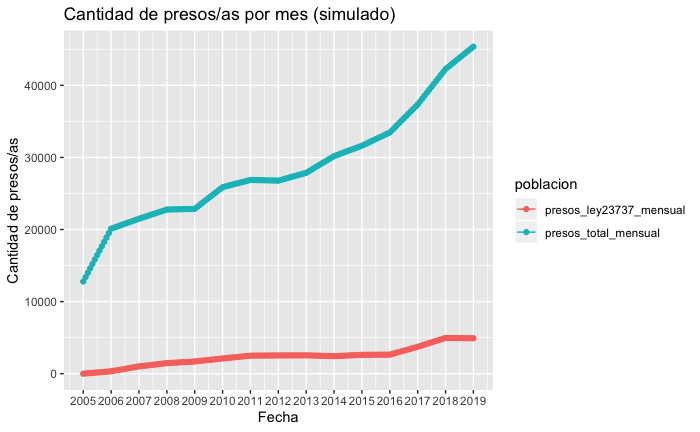

Uso el conjunto de datos de presupuestos de spb y le agrego 2019

```r
presupuesto_spb_2 <- presupuesto_spb
presupuesto_spb_2 <- presupuesto_spb_2 %>% rbind(c(2019,23417065600))
print(presupuesto_spb_2)
```

| anio | presupuesto |
| --- | --- |
| 2005 | 480095252 |
| 2006 | 568460089 |
| 2007 | 840723598 |
| 2008 | 977027549 |
| 2009 | 1173467090 |
| 2010 | 1444603505 |
| 2011 | 1897422230 |
| 2012 | 2534895960 |
| 2013 | 3330242960 |
| 2014 | 4319197000 |

[output cut: 5 more lines]

Calculo la proporcion de presos por ley 23737 sobre los presos totales. Dejo solo a partir de diciembre de 2005. Creo el presupuesto mensual y lo uso para obtener el costo de presos/as por infraccion a la ley 23737 mensual.

```r
metodo2_23737 <- metodo2_23737 %>% mutate(presos_23737_relativo=presos_ley23737_mensual/presos_total_mensual) %>% inner_join(presupuesto_spb_2, by='anio')
metodo2_23737 <- metodo2_23737 %>% filter(anio > 2005 | mes==12)
metodo2_23737 <- metodo2_23737 %>% mutate(presupuesto_mensual = presupuesto/12)
metodo2_23737 <- metodo2_23737 %>% mutate(costo_presos23737_mensual= presupuesto_mensual*presos_23737_relativo)
print(metodo2_23737)
```

[output not shown]

[output cut: 159 more lines]

Grafico las distintas proporciones de presos/as por ley 23737 sobre el total de presos. La linea roja es la media de las proporciones.

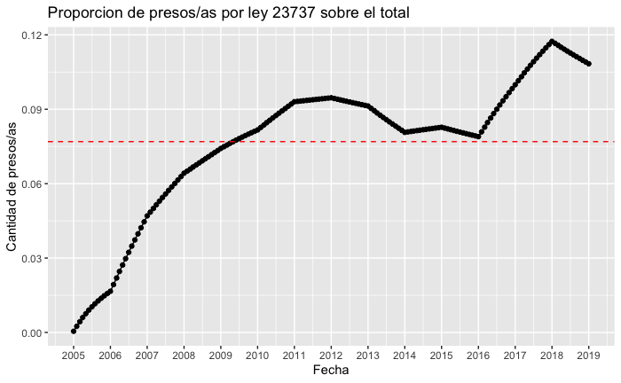

Calcular la inflacion: Utilizo la funcion anteriormente construida para estos nuevos datos.

```r
actualizados <- c()
for(i in 1:nrow(metodo2_23737)){
  presupuesto <- metodo2_23737$costo_presos23737_mensual[i]
  for(j in i:(nrow(indice_precios_consumidor)-1)){
    presupuesto <- presupuesto*(1+indice_precios_consumidor$inflacion[j+1])}
  actualizados <- c(actualizados, presupuesto)}
```

Lo agrego como una nueva columna.

```r
metodo2_23737['costo_presos23737_mensual_actualizado'] <- actualizados

sum(metodo2_23737$costo_presos23737_mensual_actualizado) # 28822343765
```

```
[1] 28822343765
```

```r
print(metodo2_23737)
```

| anio | presos_ley23737 | presos_total | cantidad_anterior_23737 | cantidad_anterior_total | mes | fecha | presos_ley23737_mensual | presos_total_mensual | presos_23737_relativo | presupuesto | presupuesto_mensual | costo_presos23737_mensual | costo_presos23737_mensual_actualizado |
| --- | --- | --- | --- | --- | --- | --- | --- | --- | --- | --- | --- | --- | --- |
| 2005 | 6 | 12788 | 6 | 12788 | 12 | 2005-12-01 | 6.00000 | 12788.00 | 0.0004691899 | 480095252 | 40007938 | 18771.32 | 547583.5 |
| 2006 | 334 | 20109 | 6 | 12788 | 1 | 2006-01-01 | 33.33333 | 13398.08 | 0.0024879180 | 568460089 | 47371674 | 117856.84 | 3394724.2 |
| 2006 | 334 | 20109 | 6 | 12788 | 2 | 2006-02-01 | 60.66667 | 14008.17 | 0.0043308070 | 568460089 | 47371674 | 205157.58 | 5885989.0 |
| 2006 | 334 | 20109 | 6 | 12788 | 3 | 2006-03-01 | 88.00000 | 14618.25 | 0.0060198724 | 568460089 | 47371674 | 285171.43 | 8084150.0 |
| 2006 | 334 | 20109 | 6 | 12788 | 4 | 2006-04-01 | 115.33333 | 15228.33 | 0.0075736018 | 568460089 | 47371674 | 358774.20 | 10072711.1 |
| 2006 | 334 | 20109 | 6 | 12788 | 5 | 2006-05-01 | 142.66667 | 15838.42 | 0.0090076344 | 568460089 | 47371674 | 426706.72 | 11924135.8 |
| 2006 | 334 | 20109 | 6 | 12788 | 6 | 2006-06-01 | 170.00000 | 16448.50 | 0.0103352889 | 568460089 | 47371674 | 489599.94 | 13615728.5 |
| 2006 | 334 | 20109 | 6 | 12788 | 7 | 2006-07-01 | 197.33333 | 17058.58 | 0.0115679790 | 568460089 | 47371674 | 547994.53 | 15146212.6 |
| 2006 | 334 | 20109 | 6 | 12788 | 8 | 2006-08-01 | 224.66667 | 17668.67 | 0.0127155416 | 568460089 | 47371674 | 602356.49 | 16555613.8 |
| 2006 | 334 | 20109 | 6 | 12788 | 9 | 2006-09-01 | 252.00000 | 18278.75 | 0.0137865007 | 568460089 | 47371674 | 653089.62 | 17790004.9 |

[output cut: 159 more lines]

Agrupo por año y calculo lo necesario

```r
metodo2_agrupado <- metodo2_23737 %>% group_by(anio) %>% summarise(presos_total_31dic=first(presos_total),
                                                           presos_23737_31dic=first(presos_ley23737),
                                                           presos_total_media_lineal= mean(presos_total_mensual),
                                                           presos_23737_media_lineal= mean(presos_ley23737_mensual),
                                                           proporcion_presos23737_medialineal=mean(presos_23737_relativo),
                                                           presupuesto=first(presupuesto),
                                                           presupuesto_mensual=first(presupuesto_mensual),
                                                           costo_presos23737_anual=sum(costo_presos23737_mensual),
                                                           costo_presos23737_anual_actualizado=sum(costo_presos23737_mensual_actualizado))

print(metodo2_agrupado)
```

| anio | presos_total_31dic | presos_23737_31dic | presos_total_media_lineal | presos_23737_media_lineal | proporcion_presos23737_medialineal | presupuesto | presupuesto_mensual | costo_presos23737_anual | costo_presos23737_anual_actualizado |
| --- | --- | --- | --- | --- | --- | --- | --- | --- | --- |
| 2005 | 12788 | 6 | 12788.00 | 6.0000 | 0.0004691899 | 480095252 | 40007938 | 1.877132e+04 | 547583.5 |
| 2006 | 20109 | 334 | 16753.54 | 183.6667 | 0.0104125225 | 568460089 | 47371674 | 5.919103e+06 | 162267385.2 |
| 2007 | 21491 | 1010 | 20857.58 | 700.1667 | 0.0334033015 | 840723598 | 70060300 | 2.808294e+07 | 664471195.0 |
| 2008 | 22769 | 1462 | 22183.25 | 1254.8333 | 0.0564850578 | 977027549 | 81418962 | 5.518746e+07 | 1071766092.9 |
| 2009 | 22858 | 1696 | 22817.21 | 1588.7500 | 0.0696262419 | 1173467090 | 97788924 | 8.170410e+07 | 1392998235.7 |
| 2010 | 25874 | 2113 | 24491.67 | 1921.8750 | 0.0783953653 | 1444603505 | 120383625 | 1.132502e+08 | 1594850648.3 |
| 2011 | 26871 | 2500 | 26414.04 | 2322.6250 | 0.0878960458 | 1897422230 | 158118519 | 1.667759e+08 | 1909361772.8 |
| 2012 | 26780 | 2534 | 26821.71 | 2518.4167 | 0.0938951606 | 2534895960 | 211241330 | 2.380145e+08 | 2222608918.2 |
| 2013 | 27860 | 2544 | 27365.00 | 2539.4167 | 0.0928087485 | 3330242960 | 277520247 | 3.090757e+08 | 2313362547.6 |
| 2014 | 30177 | 2435 | 29115.04 | 2484.9583 | 0.0854190918 | 4319197000 | 359933083 | 3.689419e+08 | 2056775049.1 |

[output cut: 5 more lines]

**COSTO FINAL DE PRESOS/AS POR INFRACCION A LA LEY 23737 (2005/2019)**

Sumo todos los años para que nos de el costo total:

```r
print(paste('Usando el Metodo 2 (aproximaciones lineales), el costo total (2005-2019) de los presos/as por infraccion a la ley 23737: ', sum(metodo2_agrupado$costo_presos23737_anual)))
```

```
[1] "Usando el Metodo 2 (aproximaciones lineales), el costo total (2005-2019) de los presos/as por infraccion a la ley 23737:  8523197836.38813"
```

```r
print(paste('Usando el Metodo 2 (aproximaciones lineales), el costo total (2005-2019) de los presos/as por infraccion a la ley 23737, actualizado por inflacion es: ', sum(metodo2_agrupado$costo_presos23737_anual_actualizado)))
```

```
[1] "Usando el Metodo 2 (aproximaciones lineales), el costo total (2005-2019) de los presos/as por infraccion a la ley 23737, actualizado por inflacion es:  28822343764.6578"
```

### Metodo 3 - **Imputacion por media**

Para este caso, imputo la cantidad de presos por mes segun la media entre el valor del 31 de diciembre del año en tratamiento con el valor del 31 de diciembre del año anterior: (año_anterior+año_actual)/2

```r
metodo3 <- metodo2_23737 %>% group_by(anio) %>% mutate(presos_total_promedio= (presos_total+cantidad_anterior_total)/2,
                                                       presos_23737_promedio= (presos_ley23737+cantidad_anterior_23737)/2)
metodo3 <- metodo3 %>% mutate(presos_23737_relativo_promedio= presos_23737_promedio/presos_total_promedio) %>%
  mutate(costo_presos23737_mensual_promedio= presupuesto_mensual*presos_23737_relativo_promedio)
print(metodo3)
```

| anio | presos_ley23737 | presos_total | cantidad_anterior_23737 | cantidad_anterior_total | mes | fecha | presos_ley23737_mensual | presos_total_mensual | presos_23737_relativo | presupuesto | presupuesto_mensual | costo_presos23737_mensual | costo_presos23737_mensual_actualizado | presos_total_promedio | presos_23737_promedio | presos_23737_relativo_promedio | costo_presos23737_mensual_promedio |
| --- | --- | --- | --- | --- | --- | --- | --- | --- | --- | --- | --- | --- | --- | --- | --- | --- | --- |
| 2005 | 6 | 12788 | 6 | 12788 | 12 | 2005-12-01 | 6.00000 | 12788.00 | 0.0004691899 | 480095252 | 40007938 | 18771.32 | 547583.5 | 12788.0 | 6.0 | 0.0004691899 | 18771.32 |
| 2006 | 334 | 20109 | 6 | 12788 | 1 | 2006-01-01 | 33.33333 | 13398.08 | 0.0024879180 | 568460089 | 47371674 | 117856.84 | 3394724.2 | 16448.5 | 170.0 | 0.0103352889 | 489599.94 |
| 2006 | 334 | 20109 | 6 | 12788 | 2 | 2006-02-01 | 60.66667 | 14008.17 | 0.0043308070 | 568460089 | 47371674 | 205157.58 | 5885989.0 | 16448.5 | 170.0 | 0.0103352889 | 489599.94 |
| 2006 | 334 | 20109 | 6 | 12788 | 3 | 2006-03-01 | 88.00000 | 14618.25 | 0.0060198724 | 568460089 | 47371674 | 285171.43 | 8084150.0 | 16448.5 | 170.0 | 0.0103352889 | 489599.94 |
| 2006 | 334 | 20109 | 6 | 12788 | 4 | 2006-04-01 | 115.33333 | 15228.33 | 0.0075736018 | 568460089 | 47371674 | 358774.20 | 10072711.1 | 16448.5 | 170.0 | 0.0103352889 | 489599.94 |
| 2006 | 334 | 20109 | 6 | 12788 | 5 | 2006-05-01 | 142.66667 | 15838.42 | 0.0090076344 | 568460089 | 47371674 | 426706.72 | 11924135.8 | 16448.5 | 170.0 | 0.0103352889 | 489599.94 |
| 2006 | 334 | 20109 | 6 | 12788 | 6 | 2006-06-01 | 170.00000 | 16448.50 | 0.0103352889 | 568460089 | 47371674 | 489599.94 | 13615728.5 | 16448.5 | 170.0 | 0.0103352889 | 489599.94 |
| 2006 | 334 | 20109 | 6 | 12788 | 7 | 2006-07-01 | 197.33333 | 17058.58 | 0.0115679790 | 568460089 | 47371674 | 547994.53 | 15146212.6 | 16448.5 | 170.0 | 0.0103352889 | 489599.94 |
| 2006 | 334 | 20109 | 6 | 12788 | 8 | 2006-08-01 | 224.66667 | 17668.67 | 0.0127155416 | 568460089 | 47371674 | 602356.49 | 16555613.8 | 16448.5 | 170.0 | 0.0103352889 | 489599.94 |
| 2006 | 334 | 20109 | 6 | 12788 | 9 | 2006-09-01 | 252.00000 | 18278.75 | 0.0137865007 | 568460089 | 47371674 | 653089.62 | 17790004.9 | 16448.5 | 170.0 | 0.0103352889 | 489599.94 |

[output cut: 159 more lines]

Actualizo por inflacion y agrupo por año

```r
actualizados <- c()
for(i in 1:nrow(metodo3)){
  presupuesto <- metodo3$costo_presos23737_mensual_promedio[i]
  for(j in i:(nrow(indice_precios_consumidor)-1)){
    presupuesto <- presupuesto*(1+indice_precios_consumidor$inflacion[j+1])
  }
  actualizados <- c(actualizados, presupuesto)
}
metodo3['costo_presos23737_mensual_promedio_actualizado'] <- actualizados

metodo3_agrupado <- metodo3 %>% group_by(anio) %>% summarise(costo_metodo3 = sum(costo_presos23737_mensual_promedio_actualizado))

print(metodo3_agrupado)
```

| anio | costo_metodo3 |
| --- | --- |
| 2005 | 547583.5 |
| 2006 | 162753576.6 |
| 2007 | 653268220.4 |
| 2008 | 1064832325.0 |
| 2009 | 1387014886.5 |
| 2010 | 1592479951.9 |
| 2011 | 1904251319.7 |
| 2012 | 2221732010.1 |
| 2013 | 2314883477.1 |
| 2014 | 2060091682.6 |

[output cut: 5 more lines]

**COSTO FINAL DE PRESOS/AS POR INFRACCION A LA LEY 23737 (2005/2019)**

Sumo todos los años para que nos de el costo total:

```r
sum(metodo3$costo_presos23737_mensual_promedio_actualizado)
```

```
[1] 28785599779
```

## Diagnostico

Por ultimo vemos una tabla comparativa para cada año segun los tres metodos utilizados

```r
comparacion_metodos <- as.data.frame(ley23737_sobre_total$anio %>%
  cbind(metodo1 %>% group_by(anio) %>% summarise(metodo1= sum(costo_presos23737_mensual_actualizado)) %>% select(metodo1)) %>%
  cbind(metodo2_23737 %>% group_by(anio) %>% summarise(metodo2_23737= sum(costo_presos23737_mensual_actualizado)) %>% select(metodo2_23737)) %>%
  cbind(metodo3 %>% group_by(anio) %>% summarise(metodo3= sum(costo_presos23737_mensual_promedio_actualizado)) %>% select(metodo3)))
colnames(comparacion_metodos) <- c('anio','metodo1_31dic','metodo2_lineal','metodo3_promedio')

print(comparacion_metodos)
```

| anio | metodo1_31dic | metodo2_lineal | metodo3_promedio |
| --- | --- | --- | --- |
| 2005 | 547583.5 | 547583.5 | 547583.5 |
| 2006 | 261555533.0 | 162267385.2 | 162753576.6 |
| 2007 | 950277273.8 | 664471195.0 | 653268220.4 |
| 2008 | 1224186498.0 | 1071766092.9 | 1064832325.0 |
| 2009 | 1486888939.1 | 1392998235.7 | 1387014886.5 |
| 2010 | 1663846125.4 | 1594850648.3 | 1592479951.9 |
| 2011 | 2025714734.5 | 1909361772.8 | 1904251319.7 |
| 2012 | 2240538031.4 | 2222608918.2 | 2221732010.1 |
| 2013 | 2274485246.5 | 2313362547.6 | 2314883477.1 |
| 2014 | 1937636381.4 | 2056775049.1 | 2060091682.6 |

[output cut: 5 more lines]

Comparo graficamente el metodo 1 y 2

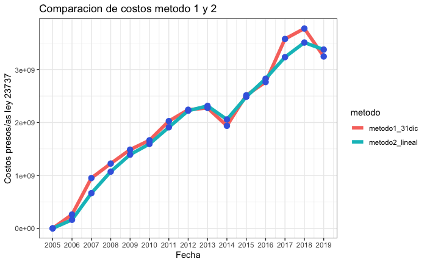

```r
ggplot(comparacion_metodos %>% select(-metodo3_promedio) %>% gather('metodo','costo_presos23737_actualizado',-anio), aes(x = anio, y = costo_presos23737_actualizado)) +
    geom_line(aes(colour = metodo), size = 2)+
    geom_point(colour = 'royalblue', size = 3)+
    scale_x_continuous(name="Fecha", breaks=seq(2005,2019,1)) +
    scale_y_continuous(name="Costos presos/as ley 23737") +
    ggtitle("Comparacion de costos metodo 1 y 2")+
    theme_bw()
```

```r
print(paste('Costos de presos/as por infraccion a la ley 23737 actualizado segun METODO 1 (imputacion al 31 dic): $',sum(comparacion_metodos$metodo1_31dic)))
```

```
[1] "Costos de presos/as por infraccion a la ley 23737 actualizado segun METODO 1 (imputacion al 31 dic): $ 29943062029.858"
```

```r
print(paste('Costos de presos/as por infraccion a la ley 23737 actualizado segun METODO 2 (imputacion lineal por mes): $',sum(comparacion_metodos$metodo2_lineal)))
```

```
[1] "Costos de presos/as por infraccion a la ley 23737 actualizado segun METODO 2 (imputacion lineal por mes): $ 28822343764.6578"
```

```r
print(paste('Costos de presos/as por infraccion a la ley 23737 actualizado segun METODO 3 (imputacion por promedio): $',sum(comparacion_metodos$metodo3_promedio)))
```

```
[1] "Costos de presos/as por infraccion a la ley 23737 actualizado segun METODO 3 (imputacion por promedio): $ 28785599778.6877"
```